# DATA1001/1901 Lab8

Chance Variability

© University of Sydney 2021

# 1 Live Demo: Simulations

We will use the same boxes from the Lab 8 Worksheet, so you can compare your results,

## 1.1 Box1

What we know:

- A box contains 1,2,3. This is the population.
- We draw 25 times from the box, with replacement. This forms the sample.
- We are interested in the properties of the **Sum** of the 25 draws.

How to model in R:

```r
# Step1: Define the box
box=c(1,2,3)

# Step2: alcuate the Mean and SD of the box
mean(box)
library(multicon)
popsd(box)

# Step3: Calculate the EV and SE of the SUM of the sample
ev = 25 * mean(box)
se = sqrt(25) * popsd(box)
c(ev,se)
```

Question: Using the appropriate normal approximation/curve estimate the chance that the sum of the sample is between 50 and 55 (inclusive).

First, work out the standard units, and draw the standard Normal curve. Calculate the probability from this curve, from your knowledge of the properties of a Normal curve, or using R.

```r
su1 = (50-ev)/se
su2 = (55-ev)/se
pnorm(su2)-pnorm(su1)

# Quicker way
pnorm(55,ev,se)-pnorm(50,ev,se)

## Adjust your calculation, using the continuity correction?  Why do we use it?
pnorm(49.5,ev,se)-pnorm(55.5,ev,se)
```

## 1.2 Box 2

- A box contains 1,2,3,4,5,6. This is the population.
- We draw 16 times from the box, with replacement. This forms the sample.
- We are interested in the properties of the **Mean** of the 16 draws.

How to model in R:

```r
# Step1: Define the box
box=c(1,2,3,4,5,6)

# Step2: Calculate the Mean and SD of the box
mean(box)
library(multicon)
popsd(box)

# Step3: Calculate the EV and SE of the MEAN of the sample
ev = mean(box)
se = popsd(box)/sqrt(16)
c(ev,se)
```

# 2 Simulate the CLT

## 2.1 Experiment with the CLT

- Experiment with the [Seeing Theory: CLT](https://students.brown.edu/seeing-theory/probability-distributions/index.html) app.
- In your own words, define the CLT in a sentence.

## 2.2 Think about the CLT

In which of the following scenarios could the CLT be applied to the sample sum or sample mean? Justify your answer.

- We extract samples of size 1 from a symmetric distribution.
- We extract samples of size 30 from a symmetric distribution.
- We extract samples of size 30 from an asymmetric distribution.
- We extract 100 samples from an asymmetric distribution.

## 2.3 Simulate simple box (symmetric)

Experiment to find out what minimum size number of draws it takes, for the distribution of the sample sum to start looking like a Normal curve.

Method: Use `replicate` to simulate 1000 samples of 10 draws (and then 100 draws) from a 0,1 box, and compare your results.

- Take 10 draws from 0,1 box [1000 replicates]

```r
set.seed(1)
box=c(0,1)
totals = replicate(1000, sum(sample(box, 10, rep = T)))
table(totals)
mean(totals)
sd(totals)
hist(totals,nclass=20)
```

- Take 100 draws from 0,1 box [1000 replicates]

```r
set.seed(1)
box=c(0,1)
totals = replicate(1000, sum(sample(box, 100, rep = T)))
table(totals)
mean(totals)
sd(totals)
hist(totals,nclass=20)
```

## 2.4 Simulate assymetric box

Experiment to find out what minimum size number of draws it takes, for the distribution of the sample sum to start looking like a Normal curve.

- Take 10 draws from 0,1,1,1,1,1,1 box [1000 replicates]

```r
set.seed(1)
box=c(0,1,1,1,1,1,1)
totals = replicate(1000, sum(sample(box, 10, rep = T)))
table(totals)
mean(totals)
sd(totals)
hist(totals,nclass=20)
```

- Take 100 draws from 0,1,1,1,1,1,1 box [1000 replicates]

```r
set.seed(1)
box=c(0,1,1,1,1,1,1)
totals = replicate(1000, sum(sample(box, 100, rep = T)))
table(totals)
mean(totals)
sd(totals)
hist(totals,nclass=20)
```

# 3 DATA 1901

**Question:** Use the Central Limit Theorem (CLT) to generate values of a standard Normal distribution from the sum of uniform random variables.

## 3.1 Uniform Distribution

- Suppose we have a sequence of independent random variables $X_{1}, X_{2} , \ldots, X_{12}$ which have a uniform distribution between 0 and 1. Formally, we write $X_{i} \sim U(0,1)$ (for $i = 1,2,\ldots 12$)
- By symmetry, it is clear that the mean of each random variable is $\frac{1}{2}$ and we can show formally that the variance (SD^2) is $\frac{1}{12}$.
- Simulate the distribution of each random variable as follows:

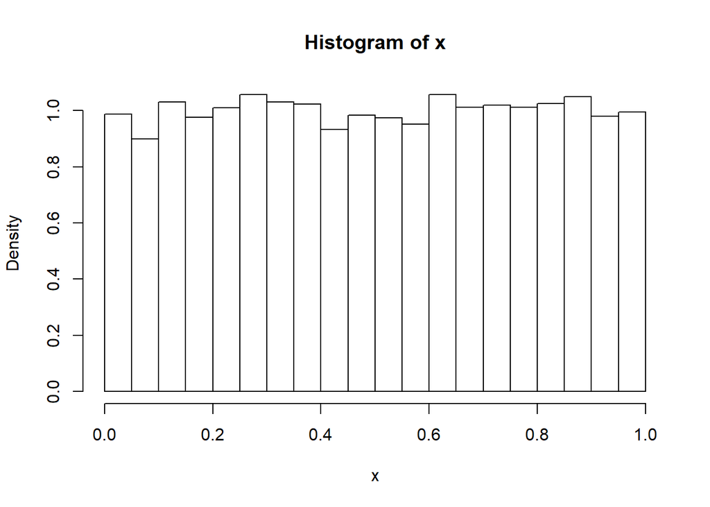

```r
# Simulate and plot U[0,1]
x = runif(10000,0,1)
hist(x, prob=T)
```

```r
mean(x) # Compare 1/2
```

```
## [1] 0.5028106
```

```r
sd(x)^2   # Compare 1/12
```

```
## [1] 0.08293793
```

## 3.2 Sum of 12 Uniforms U[0,1]

- Consider the sum $S = \sum_{i=1}^{12} X_{i}$.
- By the CLT we could propose that $S$ has approximately a Normal distribution, with mean $12 \times \frac{1}{2} = 6$ and variance $12 \times \frac{1}{12} = 1$, giving a SD of 1.
- Hence, $S - 6$ will approximately be a standard Normal N(0,1).
- Let’s see how good the approximation is.

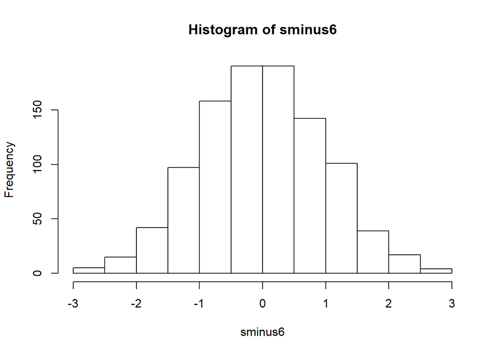

```r
# Simple nested code
sminus6 = replicate(1000, sum(runif(12,0,1))) - 6
hist(sminus6)
```

```r
mean(sminus6)
```

```
## [1] -0.01218914
```

```r
sd(sminus6)
```

```
## [1] 0.9818739
```

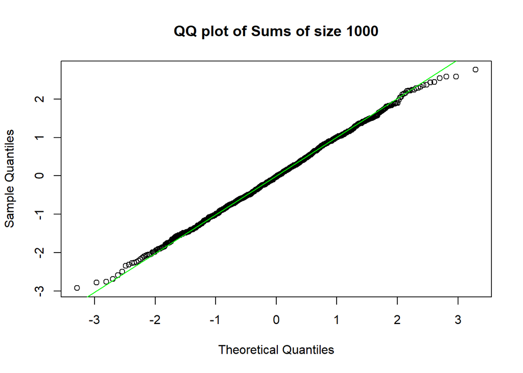

```r
qqnorm(sminus6, main=paste("QQ plot of Sums of size 1000"))
qqline(sminus6, col="green")
```

- Now experiment using a function for simulation.

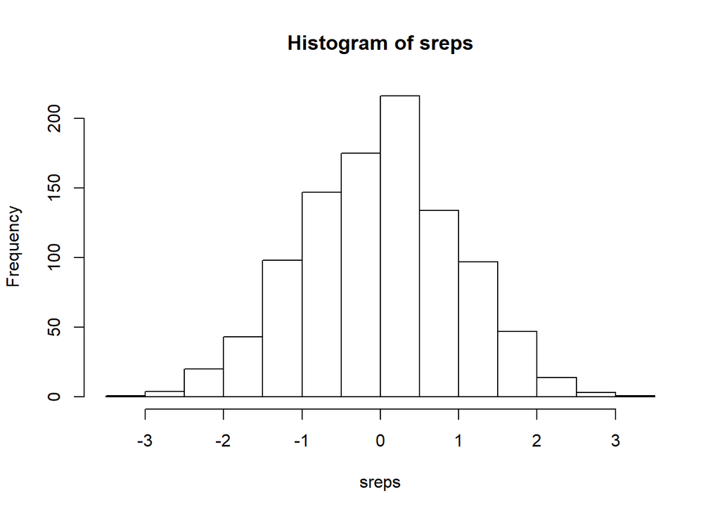

```r
# Using functions to allow choice of parameters in simulation and sim

sreps= rep(0,1000)  # empty reps variable as starting point

for(i in 1:1000)    # function to generate 1000 simulations
  {
x = runif(12,0,1)   # 12 U[0,1]
s = sum(x)          # sum of 12 U[0,1]
sreps[i] = s -6     # s - 6
}
# return(sreps)

## Results
hist(sreps)
```

```r
mean(sreps)
```

```
## [1] -0.003813142
```

```r
sd(sreps)
```

```
## [1] 0.9955794
```

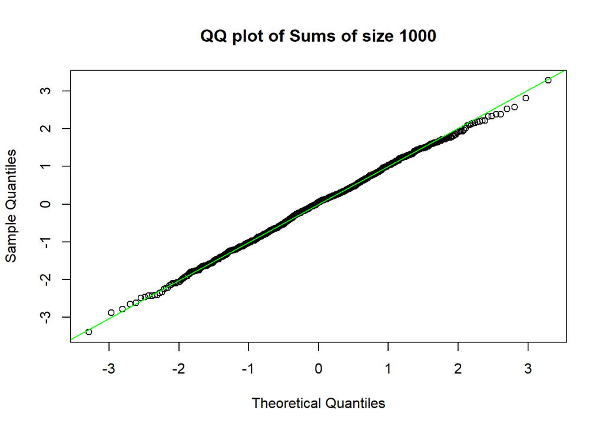

```r
qqnorm(sreps, main=paste("QQ plot of Sums of size 1000"))
qqline(sreps, col="green")
```